# Corp Bond Factors

### Corporate Bond Factor Analysis

Data set: *Dickerson, Alexander and Robotti, Cesare and Rossetti, Giulio, The Corporate Bond Factor Replication Crisis (January 18, 2026). Available at SSRN: https://ssrn.com/abstract*

A 50-year monthly database of bond portfolios grouped by quantitative factors, used to evaluate fixed-income returns, turnover, and liquidity.

Initial Finding: High-yield systematic momentum factors (sysmom) demonstrate the strongest cumulative performance, with final values ranging from 8.09 to 21.65, significantly outperforming investment-grade strategies which cluster between 2.09 and 2.42.

```python
pip install pandas pyarrow
```

```python
import pandas as pd

df = pd.read_parquet('bond.parquet')

print(df.head())
print(df.tail())
```

```
        date    return  turnover  count factor  freq leg weighting  \
0 1973-01-31       NaN       NaN    NaN    age     1   l        ew
1 1973-02-28  0.004578  1.000000   58.0    age     1   l        ew
2 1973-03-31 -0.001760  0.002449   58.0    age     1   l        ew
3 1973-04-30  0.012251  0.033898   59.0    age     1   l        ew
4 1973-05-31 -0.006688  0.033333   60.0    age     1   l        ew

  rating_type return_type  num_portfolios
0         all         dur              10
1         all         dur              10
2         all         dur              10
3         all         dur              10
4         all         dur              10
              date    return  turnover   count  factor  freq leg weighting  \
2426107 2024-08-31  0.010634  0.444108  1738.0  ytm_ig     1   s        vw
2426108 2024-09-30  0.007104  0.247263  1729.0  ytm_ig     1   s        vw
2426109 2024-10-31 -0.016720  0.278560  1752.0  ytm_ig     1   s        vw
2426110 2024-11-30  0.001508  0.247612  1740.0  ytm_ig     1   s        vw
2426111 2024-12-31 -0.006198  0.273381  1693.0  ytm_ig     1   s        vw

        rating_type return_type  num_portfolios
2426107          ig         exc               5
2426108          ig         exc               5
2426109          ig         exc               5
2426110          ig         exc               5
2426111          ig         exc               5
```

```python
print(df['factor'].unique())

print(f"Date range: {df['date'].min()} to {df['date'].max()}")
```

```
['age' 'age_hy' 'age_ig' 'ami' 'ami_hy' 'ami_ig' 'ami_v' 'ami_v_hy'
 'ami_v_ig' 'ar_sprd' 'ar_sprd_hy' 'ar_sprd_ig' 'b_amd' 'b_amd*'
 'b_amd_hy' 'b_amd_hy*' 'b_amd_ig*' 'b_amd_m*' 'b_amd_m_hy' 'b_amd_m_hy*'
 'b_amd_m_ig*' 'b_coskew' 'b_coskew*' 'b_coskew_hy' 'b_coskew_hy*'
 'b_coskew_ig*' 'b_cpi_vol6*' 'b_cpi_vol6_hy*' 'b_cpi_vol6_ig*' 'b_cptlt'
 'b_cptlt_hy' 'b_cptlt_ig' 'b_credit*' 'b_credit_hy*' 'b_credit_ig*'
 'b_crf' 'b_crf_hy' 'b_crf_ig' 'b_dcpi' 'b_dcpi_hy' 'b_dcpi_ig'
 'b_dcredit*' 'b_dcredit_hy*' 'b_dcredit_ig*' 'b_defb' 'b_defb_hy'
 'b_defb_ig' 'b_drf' 'b_drf_hy' 'b_drf_ig' 'b_dunc' 'b_dunc*' 'b_dunc3*'
 'b_dunc3_hy*' 'b_dunc3_ig*' 'b_dunc6*' 'b_dunc6_hy*' 'b_dunc6_ig*'
 'b_dunc_hy' 'b_dunc_hy*' 'b_dunc_ig*' 'b_duncf' 'b_duncf*' 'b_duncf_hy'
 'b_duncf_hy*' 'b_duncf_ig' 'b_duncf_ig*' 'b_duncr*' 'b_duncr_hy*'
 'b_duncr_ig*' 'b_dvix' 'b_dvix*' 'b_dvix_dn' 'b_dvix_dn_hy'
 'b_dvix_dn_ig' 'b_dvix_hy' 'b_dvix_ig*' 'b_dvix_up' 'b_dvix_up_hy'
 'b_dvix_up_ig*' 'b_dvix_va' 'b_dvix_va_hy' 'b_dvix_va_ig' 'b_dvix_va_ig*'
 'b_dvix_vp' 'b_dvix_vp*' 'b_dvix_vp_hy' 'b_dvix_vp_hy*' 'b_dvix_vp_ig'
 'b_dvix_vp_ig*' 'b_dvixd*' 'b_dvixd_hy' 'b_dvixd_hy*' 'b_dvixd_ig*'
 'b_epu*' 'b_epu_hy*' 'b_epu_ig*' 'b_epum*' 'b_epum_hy' 'b_epum_hy*'
 'b_epum_ig*' 'b_eput*' 'b_eput_hy*' 'b_eput_ig*' 'b_illiq' 'b_illiq*'
 'b_illiq_hy' 'b_illiq_ig*' 'b_lrf' 'b_lrf_hy' 'b_lrf_ig' 'b_lvl' 'b_lvl*'
 'b_lvl_hy' 'b_lvl_hy*' 'b_lvl_ig' 'b_mktb' 'b_mktb_dn' 'b_mktb_dn_hy'
 'b_mktb_dn_ig' 'b_mktb_hy' 'b_mktb_ig' 'b_mktb_mkt' 'b_mktb_mkt_hy'
 'b_mktb_mkt_ig' 'b_mktb_up' 'b_mktb_up_hy' 'b_mktb_up_ig' 'b_mktbx_dcapm'
 'b_mktbx_dcapm_hy' 'b_mktbx_dcapm_ig' 'b_mktrf_mkt' 'b_mktrf_mkt*'
 'b_mktrf_mkt_hy' 'b_mktrf_mkt_hy*' 'b_mktrf_mkt_ig' 'b_mktrf_mkt_ig*'
 'b_psb' 'b_psb_hy' 'b_psb_ig' 'b_psb_m' 'b_psb_m_hy' 'b_psb_m_ig' 'b_rsj'
 'b_rsj*' 'b_rsj_hy' 'b_rsj_ig' 'b_rsj_ig*' 'b_rvol' 'b_rvol_hy'
 'b_rvol_ig*' 'b_term_dcapm' 'b_term_dcapm*' 'b_term_dcapm_hy'
 'b_term_dcapm_ig' 'b_termb*' 'b_termb_hy*' 'b_termb_ig' 'b_termb_ig*'
 'b_unc*' 'b_unc_hy*' 'b_unc_ig*' 'b_vix*' 'b_vix_hy*' 'b_vix_ig*' 'b_ysp'
 'b_ysp*' 'b_ysp_hy' 'b_ysp_ig*' 'bbtm' 'bbtm_hy' 'bbtm_ig' 'convx'
 'convx*' 'convx_hy*' 'convx_ig' 'cs' 'cs_hy' 'cs_ig' 'cs_mu12_1'
 'cs_mu12_1_hy' 'cs_mu12_1_ig' 'cs_sprd' 'cs_sprd_hy' 'cs_sprd_ig'
 'db_mkt' 'db_mkt*' 'db_mkt_hy' 'db_mkt_ig' 'dcs6*' 'dcs6_hy*' 'dcs6_ig*'
 'dkurt*' 'dkurt_hy' 'dkurt_hy*' 'dkurt_ig' 'dkurt_ig*' 'dskew' 'dskew*'
 'dskew_hy*' 'dskew_ig' 'dvol' 'dvol_hy' 'dvol_idio' 'dvol_idio_hy'
 'dvol_idio_ig' 'dvol_ig' 'dvol_sys' 'dvol_sys_hy' 'dvol_sys_ig' 'es_90'
 'es_90_hy' 'es_90_ig' 'idimom12_1' 'idimom12_1_hy' 'idimom12_1_ig'
 'idimom3_1' 'idimom3_1_hy' 'idimom3_1_ig*' 'idimom6_1' 'idimom6_1_hy'
 'idimom6_1_ig' 'ilq' 'ilq_hy' 'ilq_ig' 'iltr24_3' 'iltr24_3*'
```

[output cut: 12 more lines]

```
 'mom6_1_ig*' 'mom9_1*' 'mom9_1_hy' 'mom9_1_hy*' 'mom9_1_ig*' 'p_fht'
 'p_fht_hy' 'p_fht_ig' 'p_zro' 'p_zro_hy' 'p_zro_ig' 'pi' 'pi_hy' 'pi_hy*'
 'pi_ig' 'rkt' 'rkt*' 'rkt_hy' 'rkt_ig' 'rkt_ig*' 'roll' 'roll_hy'
 'roll_ig' 'rsj*' 'rsj_hy*' 'rsj_ig*' 'rsk*' 'rsk_hy*' 'rsk_ig' 'rsk_ig*'
 'rvol' 'rvol_hy' 'rvol_ig' 'spd_abs' 'spd_abs_hy' 'spd_abs_ig' 'spd_rel'
 'spd_rel_hy' 'spd_rel_ig' 'str*' 'str_hy*' 'str_ig*' 'sysmom12_1*'
 'sysmom12_1_hy' 'sysmom12_1_hy*' 'sysmom12_1_ig*' 'sysmom3_1*'
 'sysmom3_1_hy' 'sysmom3_1_hy*' 'sysmom3_1_ig*' 'sysmom6_1' 'sysmom6_1*'
 'sysmom6_1_hy' 'sysmom6_1_hy*' 'sysmom6_1_ig*' 'sze*' 'sze_hy*' 'sze_ig*'
 'tmat' 'tmat_hy' 'tmat_hy*' 'tmat_ig' 'val_hz' 'val_hz_dts'
 'val_hz_dts_hy' 'val_hz_dts_ig' 'val_hz_hy' 'val_hz_ig' 'val_ipr'
 'val_ipr_dts' 'val_ipr_dts_hy' 'val_ipr_dts_ig' 'val_ipr_hy' 'val_ipr_ig'
 'var_90' 'var_90_hy' 'var_90_ig' 'var_95' 'var_95_hy' 'var_95_ig' 'vov'
 'vov_hy' 'vov_ig' 'ytm' 'ytm_hy' 'ytm_ig']
Date range: 1973-01-31 00:00:00 to 2024-12-31 00:00:00
```

#### Dataset is built on the assumption of baskets. Not looking for "one lucky bond".

#### Instead of seeing a row for a GE 5% 2030 bond, the data shows the performance of a group of bonds that share a characteristic

```
Average bonds per portfolio: 530
Max bonds in a single portfolio: 5408
```

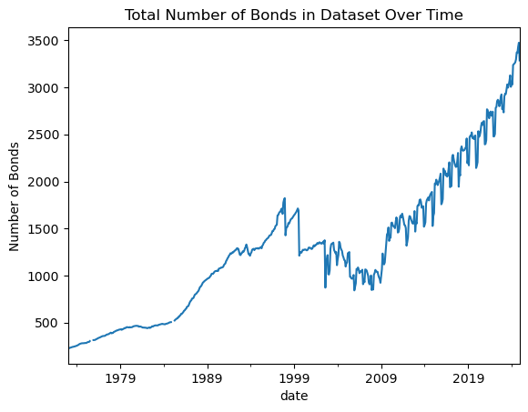

```python
print(f"Average bonds per portfolio: {df['count'].mean():.0f}")
print(f"Max bonds in a single portfolio: {df['count'].max():.0f}")

market_size = df[df['factor'] == 'age_ig'].groupby('date')['count'].max()
market_size.plot(title='Total Number of Bonds in Dataset Over Time', ylabel='Number of Bonds')
```

```
Current Bonds in Factor (as of 2024-12-31): 1564
Average Bonds over time: 634
Range: 114 to 1723 bonds
Total Years: 51.92
Annualized Return (CAGR): 12.21%
```

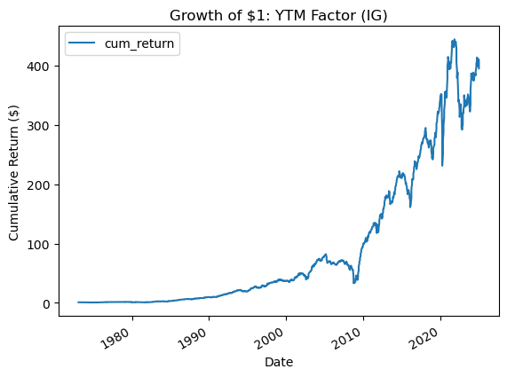

```python
import matplotlib.pyplot as plt
import pandas as pd

target = df[(df['factor'] == 'ytm_ig') &
            (df['leg'] == 'l') &
            (df['weighting'] == 'vw')].copy()

target = target.sort_values('date')
target['cum_return'] = (1 + target['return'].fillna(0)).cumprod()

clean_target = target.dropna(subset=['cum_return'])
v_initial = clean_target['cum_return'].iloc[0]
v_final = clean_target['cum_return'].iloc[-1]
years = (clean_target['date'].max() - clean_target['date'].min()).days / 365.25
cagr = (v_final / v_initial) ** (1 / years) - 1

avg_bonds = target['count'].mean()
min_bonds = target['count'].min()
max_bonds = target['count'].max()
current_bonds = target['count'].iloc[-1]

print(f"Current Bonds in Factor (as of {target['date'].iloc[-1].date()}): {current_bonds:.0f}")
print(f"Average Bonds over time: {avg_bonds:.0f}")
print(f"Range: {min_bonds:.0f} to {max_bonds:.0f} bonds")

print(f"Total Years: {years:.2f}")
print(f"Annualized Return (CAGR): {cagr:.2%}")

target.plot(x='date', y='cum_return', title='Growth of $1: YTM Factor (IG)')
plt.xlabel('Date')
plt.ylabel('Cumulative Return ($)')
plt.show()
```

```python
bond_counts = df.groupby('factor')['count'].mean().sort_values(ascending=False)

print("TOP 5 (Broadest Portfolios)")
print(bond_counts.head(5))

mid_idx = len(bond_counts) // 2
print("MIDDLE 5 (Average Sized Portfolios)")
print(bond_counts.iloc[mid_idx-2 : mid_idx+3])

print("BOTTOM 5 (Most Selective Portfolios)")
print(bond_counts.tail(5))
```

```
TOP 5 (Broadest Portfolios)
factor
p_zro_ig      1263.537313
p_fht_ig      1202.753731
spd_abs_ig    1153.823383
spd_rel_ig    1153.786070
roll_ig       1148.547264
Name: count, dtype: float64
MIDDLE 5 (Average Sized Portfolios)
factor
str*         534.075881
sze*         524.343631
mom3_1       520.569331
cs_mu12_1    499.834702
mom6_1       494.134426
Name: count, dtype: float64
BOTTOM 5 (Most Selective Portfolios)
factor
sysmom3_1_hy*     192.432283
sysmom12_1_hy     192.427861
sysmom12_1_hy*    192.377741
sysmom6_1_hy*     192.296296
sysmom6_1_hy      192.262392
Name: count, dtype: float64
```

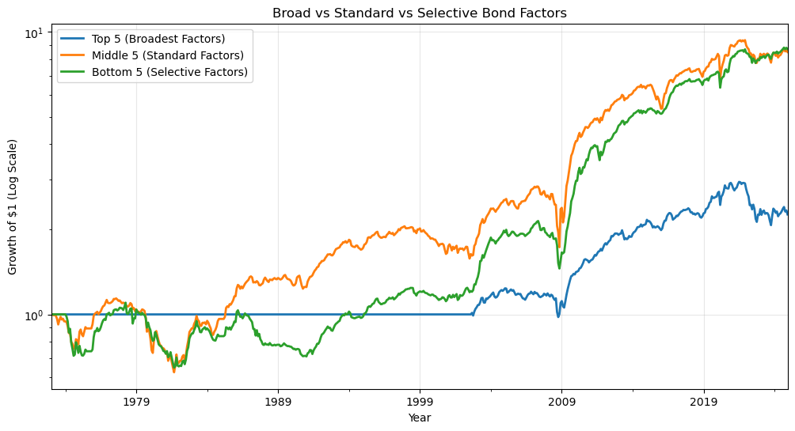

```
Final Value of $1 in Top 5:  $2.26
Final Value of $1 in Mid 5:  $8.49
Final Value of $1 in Bot 5:  $8.70
```

```python
import matplotlib.pyplot as plt
import pandas as pd

top_5_factors = ['p_zro_ig', 'p_fht_ig', 'spd_abs_ig', 'spd_rel_ig', 'roll_ig']
mid_5_factors = ['str*', 'sze*', 'mom3_1', 'cs_mu12_1', 'mom6_1']
bot_5_factors = ['sysmom3_1_hy*', 'sysmom12_1_hy', 'sysmom12_1_hy*', 'sysmom6_1_hy*', 'sysmom6_1_hy']

# Excess returns to slice data
clean_df = df[
    (df['leg'] == 'l') &
    (df['weighting'] == 'vw') &
    (df['return_type'] == 'exc')
].copy()

def get_cumulative_performance(factor_list):
    group_returns = clean_df[clean_df['factor'].isin(factor_list)]
    monthly_avg = group_returns.groupby('date')['return'].mean().sort_index()

    # (1+r1)*(1+r2)...
    return (1 + monthly_avg.fillna(0)).cumprod()

top_perf = get_cumulative_performance(top_5_factors)
mid_perf = get_cumulative_performance(mid_5_factors)
bot_perf = get_cumulative_performance(bot_5_factors)

plt.figure(figsize=(12, 6))
top_perf.plot(label='Top 5 (Broadest Factors)', linewidth=2)
mid_perf.plot(label='Middle 5 (Standard Factors)', linewidth=2)
bot_perf.plot(label='Bottom 5 (Selective Factors)', linewidth=2)

plt.yscale('log') # Log scale for % growth
plt.title('Broad vs Standard vs Selective Bond Factors')
plt.ylabel('Growth of $1 (Log Scale)')
plt.xlabel('Year')
plt.legend()
plt.grid(True, alpha=0.3)
plt.show()

print(f"Final Value of $1 in Top 5:  ${top_perf.iloc[-1]:.2f}")
print(f"Final Value of $1 in Mid 5:  ${mid_perf.iloc[-1]:.2f}")
print(f"Final Value of $1 in Bot 5:  ${bot_perf.iloc[-1]:.2f}")
```

### Sharpe Ratio

```python
import numpy as np

def get_stats(factor_list, name):
    group_returns = clean_df[clean_df['factor'].isin(factor_list)]
    monthly_avg = group_returns.groupby('date')['return'].mean()

    ann_return = monthly_avg.mean() * 12
    ann_vol = monthly_avg.std() * np.sqrt(12)
    sharpe = ann_return / ann_vol

    return {'Group': name, 'Ann. Return': ann_return, 'Ann. Volatility': ann_vol, 'Sharpe Ratio': sharpe}

results = [
    get_stats(top_5_factors, 'Top 5 (Broad)'),
    get_stats(mid_5_factors, 'Middle 5 (Standard)'),
    get_stats(bot_5_factors, 'Bottom 5 (Selective)')
]

stats_df = pd.DataFrame(results)
print(stats_df.to_string(index=False))
```

```
               Group  Ann. Return  Ann. Volatility  Sharpe Ratio
       Top 5 (Broad)     0.040050         0.083698      0.478502
 Middle 5 (Standard)     0.047717         0.110669      0.431168
Bottom 5 (Selective)     0.047444         0.092929      0.510542
```

### Simple transaction cost analysis using "average" bond premiums depending on liquidity

```python
import pandas as pd
import numpy as np

costs = {
    'broad': 0.0010,    # 10 bps (IG Liquidity)
    'standard': 0.0025, # 25 bps (Mid-tier)
    'selective': 0.0040 # 40 bps (HY=Niche Liquidity)
}

def get_net_stats(factor_list, cost_rate, name):
    mask = (df['factor'].isin(factor_list)) & (df['leg'] == 'l') & (df['weighting'] == 'vw')
    group = df[mask].copy()

    monthly = group.groupby('date').agg({'return': 'mean', 'turnover': 'mean'}).sort_index()

    # Net Return = Gross - (Turnover * Cost)
    monthly['net_return'] = monthly['return'] - (monthly['turnover'] * cost_rate)

    final_wealth = (1 + monthly['net_return'].fillna(0)).cumprod().iloc[-1]
    ann_return = monthly['net_return'].mean() * 12
    ann_vol = monthly['net_return'].std() * np.sqrt(12)
    sharpe = ann_return / ann_vol if ann_vol != 0 else 0

    return {
        'Group': name,
        'Final Net Value ($)': round(final_wealth, 2),
        'Ann. Net Return': f"{ann_return:.2%}",
        'Ann. Net Vol': f"{ann_vol:.2%}",
        'Net Sharpe': round(sharpe, 3)
    }

top_5 = ['p_zro_ig', 'p_fht_ig', 'spd_abs_ig', 'spd_rel_ig', 'roll_ig']
mid_5 = ['str*', 'sze*', 'mom3_1', 'cs_mu12_1', 'mom6_1']
bot_5 = ['sysmom3_1_hy*', 'sysmom12_1_hy', 'sysmom12_1_hy*', 'sysmom6_1_hy*', 'sysmom6_1_hy']

results = [
    get_net_stats(top_5, costs['broad'], 'Top 5 (Broad)'),
    get_net_stats(mid_5, costs['standard'], 'Middle 5 (Standard)'),
    get_net_stats(bot_5, costs['selective'], 'Bottom 5 (Selective)')
]

summary_df = pd.DataFrame(results)
print("Performance after transaction costs")
print(summary_df.to_string(index=False))
```

```
Performance after transaction costs
               Group  Final Net Value ($) Ann. Net Return Ann. Net Vol  Net Sharpe
       Top 5 (Broad)                 1.38           1.67%        6.95%       0.241
 Middle 5 (Standard)                 4.43           3.50%       11.01%       0.318
Bottom 5 (Selective)                 3.75           3.28%       11.34%       0.289
```

```python
import numpy as np
import pandas as pd

# Transaction costs
costs = {
    'top': 0.0010,     # 10 bps
    'mid': 0.0025,     # 25 bps
    'bot': 0.0040      # 40 bps
}

def get_net_stats(factor_list, cost_rate, name):
    mask = (df['factor'].isin(factor_list)) & (df['leg'] == 'l') & (df['weighting'] == 'vw')
    group = df[mask].copy()

    monthly = group.groupby('date').agg({'return': 'mean', 'turnover': 'mean'})

    # Net Return: Return - (Turnover * Cost)
    monthly['net_return'] = monthly['return'] - (monthly['turnover'] * cost_rate)

    ann_net_return = monthly['net_return'].mean() * 12
    ann_net_vol = monthly['net_return'].std() * np.sqrt(12)
    net_sharpe = ann_net_return / ann_net_vol

    return {
        'Group': name,
        'Net Ann. Return': f"{ann_net_return:.2%}",
        'Net Ann. Vol': f"{ann_net_vol:.2%}",
        'Net Sharpe': round(net_sharpe, 3)
    }

net_results = [
    get_net_stats(top_5, costs['top'], 'Top 5 (Broad)'),
    get_net_stats(mid_5, costs['mid'], 'Middle 5 (Std)'),
    get_net_stats(bot_5, costs['bot'], 'Bottom 5 (Selective)')
]

print(pd.DataFrame(net_results))
```

```
                  Group Net Ann. Return Net Ann. Vol  Net Sharpe
0         Top 5 (Broad)           1.67%        6.95%       0.241
1        Middle 5 (Std)           3.50%       11.01%       0.318
2  Bottom 5 (Selective)           3.28%       11.34%       0.289
```

```python
import pandas as pd
import numpy as np

df = pd.read_parquet('bond.parquet')
df['date'] = pd.to_datetime(df['date'])

groups_config = {
    "Top 5 (Broadest/IG)": {
        'factors': ['p_zro_ig', 'p_fht_ig', 'spd_abs_ig', 'spd_rel_ig', 'roll_ig'],
        'cost': 0.0010
    },
    "Middle 5 (Balanced/Standard)": {
        'factors': ['str*', 'sze*', 'mom3_1', 'cs_mu12_1', 'mom6_1'],
        'cost': 0.0025
    },
    "Bottom 5 (Selective/HY)": {
        'factors': ['sysmom3_1_hy*', 'sysmom12_1_hy', 'sysmom12_1_hy*', 'sysmom6_1_hy*', 'sysmom6_1_hy'],
        'cost': 0.0040
    }
}

all_factor_results = []

for group_name, config in groups_config.items():
    cost_rate = config['cost']
    for factor in config['factors']:
        f_subset = df[(df['factor'] == factor) & (df['leg'] == 'l') & (df['weighting'] == 'vw')].copy()

        if f_subset.empty: continue

        r_type = 'exc' if 'exc' in f_subset['return_type'].unique() else f_subset['return_type'].unique()[0]
        f_data = f_subset[f_subset['return_type'] == r_type].sort_values('date')

        # Annualized Return: ((Final Value)^(1/years)) - 1
        n_years = len(f_data) / 12
        final_val = (1 + f_data['return'].fillna(0)).cumprod().iloc[-1]
        ann_return = (final_val ** (1/n_years)) - 1

        avg_turnover = f_data['turnover'].mean()
        avg_bonds = f_data['count'].mean()
        start_date = f_data['date'].min().strftime('%Y-%m-%d')

        # Sharpe
        ann_vol = f_data['return'].std() * np.sqrt(12)
        sharpe = (f_data['return'].mean() * 12) / ann_vol if ann_vol > 0 else 0

        f_data['net_return'] = f_data['return'] - (f_data['turnover'].fillna(0) * cost_rate)
        net_ann_vol = f_data['net_return'].std() * np.sqrt(12)
        net_sharpe = (f_data['net_return'].mean() * 12) / net_ann_vol if net_ann_vol > 0 else 0

        all_factor_results.append({
            "Group": group_name,
            "Factor": factor,
            "Ann. Return": f"{ann_return:.2%}",
            "Start": start_date,
            "Bonds": int(avg_bonds),
            "Sharpe": round(sharpe, 3),
            "Net Sharpe": round(net_sharpe, 3)
        })

summary_df = pd.DataFrame(all_factor_results)

print("SUMMARY FINDINGS")
print(summary_df.sort_values(['Group', 'Net Sharpe'], ascending=[True, False]).to_string(index=False))
```

```
SUMMARY FINDINGS
                       Group         Factor Ann. Return      Start  Bonds  Sharpe  Net Sharpe
     Bottom 5 (Selective/HY) sysmom12_1_hy*       6.04% 1973-01-31    145   0.424       0.278
     Bottom 5 (Selective/HY)  sysmom12_1_hy       4.10% 1973-01-31    143   0.503       0.217
     Bottom 5 (Selective/HY)  sysmom3_1_hy*       6.09% 1973-01-31    145   0.444       0.193
     Bottom 5 (Selective/HY)   sysmom6_1_hy       4.36% 1973-01-31    143   0.498       0.185
Middle 5 (Balanced/Standard)      cs_mu12_1       5.05% 1973-01-31    369   0.422       0.379
Middle 5 (Balanced/Standard)           sze*       4.17% 1973-01-31    350   0.315       0.243
Middle 5 (Balanced/Standard)         mom6_1       3.46% 1973-01-31    370   0.437       0.095
Middle 5 (Balanced/Standard)           str*       4.20% 1973-01-31    399   0.384      -0.011
Middle 5 (Balanced/Standard)         mom3_1       3.48% 1973-01-31    390   0.425      -0.018
         Top 5 (Broadest/IG)       p_fht_ig       1.63% 1973-01-31    761   0.469       0.307
         Top 5 (Broadest/IG)     spd_rel_ig       1.65% 1973-01-31    828   0.477       0.301
         Top 5 (Broadest/IG)        roll_ig       1.72% 1973-01-31    778   0.468       0.299
         Top 5 (Broadest/IG)       p_zro_ig       1.43% 1973-01-31    619   0.528       0.286
         Top 5 (Broadest/IG)     spd_abs_ig       1.44% 1973-01-31    828   0.434       0.252
```

Top 5 (Broad/IG): These act as reliable anchors with low returns (~1.5%) but minimal cost decay; because IG bonds are liquid, you keep almost every dollar you earn.

Middle 5 (Balanced): These are the efficiency winners (notably cs_mu12_1), hitting the sweet spot by capturing higher returns (~5%) while maintaining enough diversification to protect Net Sharpe from trading costs.

### Indicator categories to investigate further

```python
import pandas as pd
import numpy as np

df = pd.read_parquet('bond.parquet')

style_map = {
    'Momentum': ['mom', 'imom', 'idimom', 'str*'],
    'Value/Yield': ['val', 'ytm', 'bbtm', 'ysp', 'pi'],
    'Spreads': ['sprd', 'cs_mu', 'cs_sprd', 'ar_sprd'],
    'Risk/Vol': ['vol', 'rvol', 'ivol', 'skew', 'kurt', 'var', 'es_90', 'vov'],
    'Liquidity': ['illiq', 'lix', 'ami', 'fht', 'roll', 'spd_abs', 'spd_rel'],
    'Size/Age': ['sze', 'age', 'tmat', 'p_zro'],
    'Betas/Market': ['b_', 'mkt', 'term', 'defb', 'drf', 'crf', 'lrf'],
    'Macro/Inflation': ['cpi', 'epu', 'unc', 'dcpi', 'vix']
}

def get_style(factor_name):
    for style, keywords in style_map.items():
        if any(key in factor_name for key in keywords):
            return style
    return 'Uncategorized'

clean_df = df[(df['leg'] == 'l') & (df['weighting'] == 'vw')].copy()
clean_df['Style'] = clean_df['factor'].apply(get_style)

# Annualised results
results = []
for style in clean_df['Style'].unique():
    subset = clean_df[clean_df['Style'] == style]

    ann_ret = subset['return'].mean() * 12
    ann_vol = subset['return'].std() * np.sqrt(12)
    ann_turnover = subset['turnover'].mean() * 12

    # 25bps average cost
    net_ret = ann_ret - (ann_turnover * 0.0025)

    results.append({
        'Style': style,
        'Count': subset['factor'].nunique(),
        'Ann. Return': f"{ann_ret:.2%}",
        'Turnover': f"{ann_turnover:.1%}",
        'Net Sharpe': round(net_ret / ann_vol, 3) if ann_vol > 0 else 0
    })

print(pd.DataFrame(results).sort_values('Net Sharpe', ascending=False).to_string(index=False))
```

```
        Style  Count Ann. Return Turnover  Net Sharpe
  Value/Yield     30       6.88%   639.5%       0.433
      Spreads      9       7.50%   514.6%       0.432
 Betas/Market    130       6.57%   496.2%       0.412
     Size/Age     13       5.72%   440.0%       0.366
     Risk/Vol     50       6.71%   726.2%       0.337
Uncategorized     50       6.01%   835.0%       0.327
     Momentum     47       5.94%  1181.0%       0.277
    Liquidity     24       5.99%  1430.6%       0.173
```

The breakdown of factors indicates that the betas/market category is the most populated. This is likely because it is the preferred way for the majority of investors and traders to enter fixed income markets.

### Decay table

Methodology derived from Dickerson, Alexander and Robotti, Cesare and Rossetti, Giulio, The Corporate Bond Factor Replication Crisis (January 18, 2026). Available at SSRN: https://ssrn.com/abstract

```python
decay_results = []

# 1. Define cost rates by liquidity tier
costs_tier = {
    'ig': 0.0010, # 10 bps for liquid IG
    'std': 0.0025, # 25 bps for standard
    'hy': 0.0040  # 40 bps for illiquid HY
}

for factor in summary_df['Factor'].unique():
    row = summary_df[summary_df['Factor'] == factor].iloc[0]
    raw_ret = float(row['Ann. Return'].strip('%')) / 100

    f_data = df[(df['factor'] == factor) & (df['leg'] == 'l') & (df['weighting'] == 'vw')]
    avg_turnover = f_data['turnover'].mean()

    if '_ig' in factor:
        cost_rate = costs_tier['ig']
    elif '_hy' in factor:
        cost_rate = costs_tier['hy']
    else:
        cost_rate = costs_tier['std']

    abs_cost = avg_turnover * cost_rate
    net_ret = raw_ret - abs_cost
    decay_pct = (abs_cost / raw_ret) if raw_ret > 0 else 1.0

    decay_results.append({
        'Factor': factor,
        'Raw Return': f"{raw_ret:.2%}",
        'Abs. Cost (Bps)': f"{abs_cost*10000:.1f} bps",
        'Net Return': f"{max(net_ret, 0):.2%}",
        'Profit Decay': f"{decay_pct:.1%}"
    })

decay_df = pd.DataFrame(decay_results).sort_values('Abs. Cost (Bps)', ascending=True)
print("DYNAMIC DECAY TABLE: REAL COST vs PROFIT")
print(decay_df.to_string(index=False))
```

```
DYNAMIC DECAY TABLE: REAL COST vs PROFIT
        Factor Raw Return Abs. Cost (Bps) Net Return Profit Decay
          sze*      4.17%        10.1 bps      4.07%         2.4%
      p_fht_ig      1.63%        12.0 bps      1.51%         7.4%
    spd_abs_ig      1.44%        12.9 bps      1.31%         9.0%
    spd_rel_ig      1.65%        12.9 bps      1.52%         7.8%
       roll_ig      1.72%        13.3 bps      1.59%         7.7%
      p_zro_ig      1.43%        13.5 bps      1.29%         9.4%
 sysmom12_1_hy      4.10%        21.7 bps      3.88%         5.3%
sysmom12_1_hy*      6.04%        22.3 bps      5.82%         3.7%
  sysmom6_1_hy      4.36%        25.3 bps      4.11%         5.8%
        mom6_1      3.46%        25.4 bps      3.21%         7.4%
        mom3_1      3.48%        34.1 bps      3.14%         9.8%
 sysmom3_1_hy*      6.09%        35.8 bps      5.73%         5.9%
          str*      4.20%        43.2 bps      3.77%        10.3%
     cs_mu12_1      5.05%         5.1 bps      5.00%         1.0%
```

Investigate further:

- Why are the orthogonalised sysmom factors more effective than the non-orthogonalised?
- How does each indicator/measurement fair during adverse or black swan events?
- How does the credit cycle impact each strategy?
- Find "low-maintenance" winners by identifying factors with high returns but minimal trading volume.
- Aggregate factors by "Style" (Value, Mo, Vol) to see which investment philosophy can drive P&L.
- Does blending uncorrelated styles (like Value + Momentum) create a smoother, higher Net Sharpe?